# Advanced Data Wrangling

Dr. Liu Qizhang

31 January 2019

## Introduction

This file further expands on data wrangling, how to import data from various sources into R and also how to deal with tiny data and the various ways we can combine our data that we have just imported.

## Importing Data

It is much more common for us to import data rather then to artificially create our own or to manually input it by hand. Therefore, we will cover how to import data with the use of the [tidyverse packages](https://www.tidyverse.org/) readr, readxl and tidyr. We can also import data with R-base functions. Notice that we have already made use of readr, and how to install packages in last week’s SGX questions when we had to import that data, and that dplyr and tibble are also part of tidyverse with dplyr used explicitly while tibble was used to display our data when using dplyr.

Data is stored in [delimiter-separated values](https://en.wikipedia.org/wiki/Delimiter-separated_values), the common ones that we are aware of - excel spreadsheets and google sheets are simply propriety versions of this. You may have seen csv(comma separated values) or tsv(tab-separated values) where commas “,” or tabs are used to partition the cells of data.

### Via readr

Here are some of the more common readr functions we will work with, as shown in the video. [Readr cheatsheet](https://rawgit.com/rstudio/cheatsheets/master/data-import.pdf)

However, there are still [more functions](https://cran.r-project.org/web/packages/readr/readr.pdf) in the documentation which you may explore on your own.

| Function | Format | Typical Suffix |
| --- | --- | --- |
| read_table | whitespace separated values | txt |
| read_csv | comma separated values | csv |
| read_csv2 | semicolon separated values | csv |
| read_tsv | tab delimited separated values | tsv |
| read_delim | general text file format, must specify delimiter | txt |

#### Checking format

Here we will use Prof Rafael’s murders dataset from before, which is from the *dslabs* package. Code below taken from [his github](https://rafalab.github.io/dsbook/importing-data.html), copy and run this code to copy and paste this dataset into your current working directory.

```r
install.packages("dslabs")
```

```r
library(dslabs)
dir <- system.file(package="dslabs") #extracts the location of package
filename <- file.path(dir,"extdata/murders.csv")
file.copy(filename, "murders.csv")
```

```
## [1] FALSE
```

We use readr’s *read_lines()* function to double check if it really is comma separated.

```r
library(readr)
read_lines("murders.csv", n_max = 3) #n_max - max number of lines to read
```

```
## [1] "state,abb,region,population,total" "Alabama,AL,South,4779736,135"
## [3] "Alaska,AK,West,710231,19"
```

A visual confirmation of commas and the correct file suffix means that we can use the *read_csv()* function. We can use the fullpath - e.g. c:/user//documents/rsessions/“murders.csv” or, as we previously copied the csv to our current working directory, simply use the filename “murders.csv”.

```r
dat <- read_csv("murders.csv")
```

As we used tidyverse packages for data import, displaying our data with the *head()* function display it as a tibble.

```r
head(dat)
```

```
## # A tibble: 6 x 5
##   state      abb   region population total
##   <chr>      <chr> <chr>       <dbl> <dbl>
## 1 Alabama    AL    South     4779736   135
## 2 Alaska     AK    West       710231    19
## 3 Arizona    AZ    West      6392017   232
## 4 Arkansas   AR    South     2915918    93
## 5 California CA    West     37253956  1257
## 6 Colorado   CO    West      5029196    65
```

### Via readxl

Below are the common readxl functions. The [readxl website](https://readxl.tidyverse.org/) contains more examples, I recommend reading through the usage section on the same page.

| Function | Format | Typical Suffix |
| --- | --- | --- |
| read_excel | auto detects the format | xls, xlsx |
| read_xls | original format | xls |
| read_xlsx | new excel format | xlsx |

Firstly, install the package as shown last week.

```r
install.packages("readxl")
```

```r
library(readxl)
```

Here we will use readxl’s built in datasets, many libraries have this for practice and example purposes, here datasets.xlsx contains many famous datasets such as the one below.

```r
xlsx_example <- readxl_example("datasets.xlsx")
read_excel(xlsx_example)
```

```
## readxl works best with a newer version of the tibble package.
## You currently have tibble v1.4.2.
## Falling back to column name repair from tibble <= v1.4.2.
## Message displays once per session.
```

```
## # A tibble: 150 x 5
##    Sepal.Length Sepal.Width Petal.Length Petal.Width Species
##           <dbl>       <dbl>        <dbl>       <dbl> <chr>
##  1          5.1         3.5          1.4         0.2 setosa
##  2          4.9         3            1.4         0.2 setosa
##  3          4.7         3.2          1.3         0.2 setosa
##  4          4.6         3.1          1.5         0.2 setosa
##  5          5           3.6          1.4         0.2 setosa
##  6          5.4         3.9          1.7         0.4 setosa
##  7          4.6         3.4          1.4         0.3 setosa
##  8          5           3.4          1.5         0.2 setosa
##  9          4.4         2.9          1.4         0.2 setosa
## 10          4.9         3.1          1.5         0.1 setosa
## # ... with 140 more rows
```

To simply display the worksheet names in this work book.

```r
excel_sheets(xlsx_example)
```

```
## [1] "iris"     "mtcars"   "chickwts" "quakes"
```

Either specify the sheet number (1-based indexing), or the sheet’s name

```r
read_excel(xlsx_example, sheet = "chickwts")
```

```
## # A tibble: 71 x 2
##    weight feed
##     <dbl> <chr>
##  1    179 horsebean
##  2    160 horsebean
##  3    136 horsebean
##  4    227 horsebean
##  5    217 horsebean
##  6    168 horsebean
##  7    108 horsebean
##  8    124 horsebean
##  9    143 horsebean
## 10    140 horsebean
## # ... with 61 more rows
```

```r
read_excel(xlsx_example, sheet = 3)
```

```
## # A tibble: 71 x 2
##    weight feed
##     <dbl> <chr>
##  1    179 horsebean
##  2    160 horsebean
##  3    136 horsebean
##  4    227 horsebean
##  5    217 horsebean
##  6    168 horsebean
##  7    108 horsebean
##  8    124 horsebean
##  9    143 horsebean
## 10    140 horsebean
## # ... with 61 more rows
```

### Via R-base

R-base functions such as *read.csv()* and *read.table()* can be used without having to install any libraries or having to rely on our IDE’s (RStudio) functionality.

Notice that as the tibble package displays data imported using tidyverse packages such as readr and readxl, our data is in the data.frame form instead of as a tibble.

```r
dat2 <- read.csv("murders.csv")
class(dat2)
```

```
## [1] "data.frame"
```

As we mentioned before, R is special in that it has the *factor* special variable which many statistical models in R can handle so this R-base import function will automatically convert any character strings to factors. In order to avoid this, we can use the *stringsAsFactors* keyword argument to switch off this behaviour.

```r
class(dat2$abb)
```

```
## [1] "factor"
```

```r
class(dat2$region)
```

```
## [1] "factor"
```

```r
dat3 <- read.csv("murders.csv", stringsAsFactors = FALSE)
class(dat3$abb)
```

```
## [1] "character"
```

```r
class(dat2$region)
```

```
## [1] "factor"
```

#### CSV Example

In this course we will heavily rely on the CSV file format. It has widespread use in the data science community due to its efficiency at storing large amounts of data and also as it is platform agnostic.There is also no size limit with csv files.

```r
care.data <- read.csv("hospital-data.csv")
str(care.data)
```

```
## 'data.frame':    4826 obs. of  13 variables:
##  $ Provider.Number   : Factor w/ 4826 levels "010001","010005",..: 1 2 3 4 5 6 7 8 9 10 ...
##  $ Hospital.Name     : Factor w/ 4624 levels "ABBEVILLE AREA MEDICAL CENTER",..: 3674 2203 1068 2564 857 1482 2202 3918 929 3699 ...
##  $ Address.1         : Factor w/ 4800 levels " 1200 EAST PECAN ST",..: 459 2103 1726 3926 228 1681 4182 3224 1582 2642 ...
##  $ Address.2         : logi  NA NA NA NA NA NA ...
##  $ Address.3         : logi  NA NA NA NA NA NA ...
##  $ City              : Factor w/ 3018 levels "ABBEVILLE","ABERDEEN",..: 723 278 899 1973 1560 1140 1099 250 929 2679 ...
##  $ State             : Factor w/ 56 levels "AK","AL","AR",..: 2 2 2 2 2 2 2 2 2 2 ...
##  $ ZIP.Code          : int  36301 35957 35631 36467 36049 35640 35976 35235 35968 36784 ...
##  $ County            : Factor w/ 1533 levels "","ABBEVILLE",..: 652 861 785 347 356 939 861 695 388 297 ...
##  $ Phone.Number      : num  3.35e+09 2.57e+09 2.57e+09 3.34e+09 3.34e+09 ...
##  $ Hospital.Type     : Factor w/ 4 levels "ACUTE CARE - VETERANS ADMINISTRATION",..: 2 2 2 2 2 2 2 2 2 2 ...
##  $ Hospital.Ownership: Factor w/ 14 levels "Government-Federal",..: 5 5 5 14 9 9 5 14 9 9 ...
##  $ Emergency.Services: Factor w/ 3 levels "No","Not Available",..: 3 3 3 3 3 2 3 3 3 2 ...
```

Because of the lack of file size limit, sometimes we might want to be smart about how we import data so as to save on memory space - and as a result on time taken.

While the time differences here are small due to the filesize, this can be handy when our files are 100s of gbs large.

```r
system.time(care.data<-read.csv("hospital-data.csv"))
```

```
##    user  system elapsed
##    0.08    0.02    0.09
```

```r
data.sample <- read.csv("hospital-data.csv", nrows = 5)
data.sample
```

```
##   Provider.Number                    Hospital.Name
## 1           10001 SOUTHEAST ALABAMA MEDICAL CENTER
## 2           10005    MARSHALL MEDICAL CENTER SOUTH
## 3           10006   ELIZA COFFEE MEMORIAL HOSPITAL
## 4           10007         MIZELL MEMORIAL HOSPITAL
## 5           10008      CRENSHAW COMMUNITY HOSPITAL
##                    Address.1 Address.2 Address.3     City State ZIP.Code
## 1     1108 ROSS CLARK CIRCLE        NA        NA   DOTHAN    AL    36301
## 2 2505 U S HIGHWAY 431 NORTH        NA        NA     BOAZ    AL    35957
## 3         205 MARENGO STREET        NA        NA FLORENCE    AL    35631
## 4              702 N MAIN ST        NA        NA      OPP    AL    36467
## 5        101 HOSPITAL CIRCLE        NA        NA  LUVERNE    AL    36049
##       County Phone.Number        Hospital.Type
## 1    HOUSTON   3347938701 Acute Care Hospitals
## 2   MARSHALL   2565938310 Acute Care Hospitals
## 3 LAUDERDALE   2567688400 Acute Care Hospitals
## 4  COVINGTON   3344933541 Acute Care Hospitals
## 5   CRENSHAW   3343353374 Acute Care Hospitals
##                            Hospital.Ownership Emergency.Services
## 1 Government - Hospital District or Authority                Yes
## 2 Government - Hospital District or Authority                Yes
## 3 Government - Hospital District or Authority                Yes
## 4              Voluntary non-profit - Private                Yes
## 5                                 Proprietary                Yes
```

```r
colclass <-c("character","character","character",
             "character","character","character",
             "factor", "factor", "factor",
             "character", "factor", "factor", "factor")
system.time(care.data<-read.csv("hospital-data.csv", colClasses = colclass))
```

```
##    user  system elapsed
##    0.05    0.00    0.04
```

### Via URL

Very often, we will obtain our datasets from an online source. Instead of first downloading them to be imported, we can skip a step and read them directly from the URL. In this case we will be using readr’s *read_csv()* function.

```r
url <- "https://raw.githubusercontent.com/rafalab/dslabs/master/inst/extdata/murders.csv"
dat <- read_csv(url)
```

There are also some useful functions associated with of importing data via URL.

Sometimes, you might also want to keep a local copy of the file.

```r
download.file(url, "murders.csv")
```

Additionally, it is useful to have a temporary directory or filename auto generated to manage these URL imports. We can do this with the *tempdir()* and *tempfile()* functions respectively.

```r
tempdir()
```

```
## [1] "C:\\Users\\bizlqz\\AppData\\Local\\Temp\\RtmpYXa3Ky"
```

```r
tempfile()
```

```
## [1] "C:\\Users\\bizlqz\\AppData\\Local\\Temp\\RtmpYXa3Ky\\file15585f212826"
```

Here is an example of how we might use these functions.

```r
tmp_filename <- tempfile()
download.file(url, tmp_filename)
dat <- read_csv(tmp_filename)
file.remove(tmp_filename)
```

```
## [1] TRUE
```

There are many places on the internet to source for these datasets, such as kaggle, kdnuggets. For sg related [open data](https://en.wikipedia.org/wiki/Open_data) visit [data.gov.sg](https://data.gov.sg/). There are also [european](https://data.europa.eu/euodp/en/home) and [US](https://www.data.gov/) counterparts.

### Via JSON

Sometimes open data is provided via API(Application Programming Interface), especially in cases where the data is dynamic. The interfaces make use of [JSON](https://www.json.org/), JavaScript Object Notation, which is a lightweight language independent standard used to exchange data between programs.

```javascript
{
  "firstName": "Lilian",
  "lastName": "Teo",
  "age": 42,
  "spouse": null
}
```

Notice how the data is nested in JSON format.

```javascript
{
  "firstName": "Lilian",
  "lastName": "Teo",
  "age": 42,
  "spouse": null,
  "children":[
    {
      "Name":"Melvyn",
      "age": 12
    },
    {
      "Name":"Joan",
      "age": 8
    }
    }
  ]
}
```

An example of how to import JSON files, combining our knowledge of importing from URL above.

```r
library(jsonlite)
url <- "https://api.data.gov.sg/v1/transport/carpark-availability"
data <- fromJSON(url)
a <- as.data.frame(data$items$carpark_data)
```

### Via XML

When we are obtaining our data from crawling a website, we will make use of XML - eXtensible Markup Language, which is how websites store and transport data.

```xml
<?xml version="1.0"?>
<person>
  <firstName>Lilian</firstName>
  <lastName>Teo</lastName>
  <age>32</age>
  <spouse></spouse>
</person>
```

Here is how the second example would look. Notice that XML also has a tree structure with the corresponding tags being nodes in the tree where the root node of the three has five child nodes.

```xml
<?xml version="1.0"?>
<person>
  <firstName>Lilian</firstName> <!--the data inside is called XML text-->
  <lastName>Teo</lastName>
  <age>32</age>
  <spouse></spouse>
  <children>
         <child gender="male">  <!--notice how these tags can have attributes-->
                 <name>Melvyn</name>
                 <age>12</age>
         </child>
         <child gender="female">
                 <name>Joan</name>
                 <age>8</age>
         </child>
  <children>
</person>
```

#### XML Example

XML can store all types of data while HTML text must be pre-defined. When importing XML remember to install the *XML package*. Use the *xmlParse()* function to import the data from “books.xml”.

```r
library(XML)
data <- xmlParse("books.xml")
```

Here is how the data should look.

```r
data
```

```
## <?xml version="1.0"?>
## <library>
##   <location>HSSML</location>
##   <catalog>
##     <book id="bk101" type="HardCover">
##       <author>Gambardella, Matthew</author>
##       <title>XML Developer's Guide</title>
##       <genre>Computer</genre>
##       <price>44.95</price>
##       <publish_date>2000-10-01</publish_date>
##       <description>An in-depth look at creating applications
##         with XML.</description>
##     </book>
##     <book id="bk102" type="HardCover">
##       <author>Ralls, Kim</author>
##       <title>Midnight Rain</title>
##       <genre>Fantasy</genre>
##       <price>5.95</price>
##       <publish_date>2000-12-16</publish_date>
##       <description>A former architect battles corporate zombies,
##         an evil sorceress, and her own childhood to become queen
##         of the world.</description>
##     </book>
##     <book id="bk103" type="HardCover">
##       <author>Corets, Eva</author>
##       <title>Maeve Ascendant</title>
##       <genre>Fantasy</genre>
##       <price>5.95</price>
##       <publish_date>2000-11-17</publish_date>
##       <description>After the collapse of a nanotechnology
##         society in England, the young survivors lay the
##         foundation for a new society.</description>
##     </book>
##     <book id="bk104" type="SoftCover">
##       <author>Corets, Eva</author>
##       <title>Oberon's Legacy</title>
##       <genre>Fantasy</genre>
##       <price>5.95</price>
##       <publish_date>2001-03-10</publish_date>
##       <description>In post-apocalypse England, the mysterious
```

[output cut: 69 more lines]

```
##     </book>
##     <book id="bk112" type="SoftCover">
##       <author>Galos, Mike</author>
##       <title>Visual Studio 7: A Comprehensive Guide</title>
##       <genre>Computer</genre>
##       <price>49.95</price>
##       <publish_date>2001-04-16</publish_date>
##       <description>Microsoft Visual Studio 7 is explored in depth,
##         looking at how Visual Basic, Visual C++, C#, and ASP+ are
##         integrated into a comprehensive development
##         environment.</description>
##     </book>
##   </catalog>
## </library>
##
```

Now we use the *xmlRoot()* function to access the root node of the tree.

```r
root <- xmlRoot(data)
```

*xmlChildren()* function gets use the children nodes of the tree.

```r
nodes <- xmlChildren(root) #notice the input here should be root not data
```

Below is the second child node of root, however to go even further we can get the child node of this node.

```r
a <- nodes[[2]]
a
```

```
## <catalog>
##   <book id="bk101" type="HardCover">
##     <author>Gambardella, Matthew</author>
##     <title>XML Developer's Guide</title>
##     <genre>Computer</genre>
##     <price>44.95</price>
##     <publish_date>2000-10-01</publish_date>
##     <description>An in-depth look at creating applications
##         with XML.</description>
##   </book>
##   <book id="bk102" type="HardCover">
##     <author>Ralls, Kim</author>
##     <title>Midnight Rain</title>
##     <genre>Fantasy</genre>
##     <price>5.95</price>
##     <publish_date>2000-12-16</publish_date>
##     <description>A former architect battles corporate zombies,
##         an evil sorceress, and her own childhood to become queen
##         of the world.</description>
##   </book>
##   <book id="bk103" type="HardCover">
##     <author>Corets, Eva</author>
##     <title>Maeve Ascendant</title>
##     <genre>Fantasy</genre>
##     <price>5.95</price>
##     <publish_date>2000-11-17</publish_date>
##     <description>After the collapse of a nanotechnology
##         society in England, the young survivors lay the
##         foundation for a new society.</description>
##   </book>
##   <book id="bk104" type="SoftCover">
##     <author>Corets, Eva</author>
##     <title>Oberon's Legacy</title>
##     <genre>Fantasy</genre>
##     <price>5.95</price>
##     <publish_date>2001-03-10</publish_date>
##     <description>In post-apocalypse England, the mysterious
##         agent known only as Oberon helps to create a new life
##         for the inhabitants of London. Sequel to Maeve
##         Ascendant.</description>
```

[output cut: 64 more lines]

```
##         detail, with attention to XML DOM interfaces, XSLT processing,
##         SAX and more.</description>
##   </book>
##   <book id="bk112" type="SoftCover">
##     <author>Galos, Mike</author>
##     <title>Visual Studio 7: A Comprehensive Guide</title>
##     <genre>Computer</genre>
##     <price>49.95</price>
##     <publish_date>2001-04-16</publish_date>
##     <description>Microsoft Visual Studio 7 is explored in depth,
##         looking at how Visual Basic, Visual C++, C#, and ASP+ are
##         integrated into a comprehensive development
##         environment.</description>
##   </book>
## </catalog>
```

```r
moreNodes <- xmlChildren(a)
b <- moreNodes[[2]]
b
```

```
## <book id="bk102" type="HardCover">
##   <author>Ralls, Kim</author>
##   <title>Midnight Rain</title>
##   <genre>Fantasy</genre>
##   <price>5.95</price>
##   <publish_date>2000-12-16</publish_date>
##   <description>A former architect battles corporate zombies,
##         an evil sorceress, and her own childhood to become queen
##         of the world.</description>
## </book>
```

If we knbw the structure of the XML file we can use tags or attributes to search for specific data.Here is how we just get the books.

```r
books <- getNodeSet(data,"/library/catalog/book")
books
```

```
## [[1]]
## <book id="bk101" type="HardCover">
##   <author>Gambardella, Matthew</author>
##   <title>XML Developer's Guide</title>
##   <genre>Computer</genre>
##   <price>44.95</price>
##   <publish_date>2000-10-01</publish_date>
##   <description>An in-depth look at creating applications
##         with XML.</description>
## </book>
##
## [[2]]
## <book id="bk102" type="HardCover">
##   <author>Ralls, Kim</author>
##   <title>Midnight Rain</title>
##   <genre>Fantasy</genre>
##   <price>5.95</price>
##   <publish_date>2000-12-16</publish_date>
##   <description>A former architect battles corporate zombies,
##         an evil sorceress, and her own childhood to become queen
##         of the world.</description>
## </book>
##
## [[3]]
## <book id="bk103" type="HardCover">
##   <author>Corets, Eva</author>
##   <title>Maeve Ascendant</title>
##   <genre>Fantasy</genre>
##   <price>5.95</price>
##   <publish_date>2000-11-17</publish_date>
##   <description>After the collapse of a nanotechnology
##         society in England, the young survivors lay the
##         foundation for a new society.</description>
## </book>
##
## [[4]]
## <book id="bk104" type="SoftCover">
##   <author>Corets, Eva</author>
##   <title>Oberon's Legacy</title>
##   <genre>Fantasy</genre>
```

[output cut: 88 more lines]

```
## [[12]]
## <book id="bk112" type="SoftCover">
##   <author>Galos, Mike</author>
##   <title>Visual Studio 7: A Comprehensive Guide</title>
##   <genre>Computer</genre>
##   <price>49.95</price>
##   <publish_date>2001-04-16</publish_date>
##   <description>Microsoft Visual Studio 7 is explored in depth,
##         looking at how Visual Basic, Visual C++, C#, and ASP+ are
##         integrated into a comprehensive development
##         environment.</description>
## </book>
##
## attr(,"class")
## [1] "XMLNodeSet"
```

We can further refine our search for just hard cover books.

```r
books <- getNodeSet(data, "/library/catalog/book[@type='HardCover']")
books
```

```
## [[1]]
## <book id="bk101" type="HardCover">
##   <author>Gambardella, Matthew</author>
##   <title>XML Developer's Guide</title>
##   <genre>Computer</genre>
##   <price>44.95</price>
##   <publish_date>2000-10-01</publish_date>
##   <description>An in-depth look at creating applications
##         with XML.</description>
## </book>
##
## [[2]]
## <book id="bk102" type="HardCover">
##   <author>Ralls, Kim</author>
##   <title>Midnight Rain</title>
##   <genre>Fantasy</genre>
##   <price>5.95</price>
##   <publish_date>2000-12-16</publish_date>
##   <description>A former architect battles corporate zombies,
##         an evil sorceress, and her own childhood to become queen
##         of the world.</description>
## </book>
##
## [[3]]
## <book id="bk103" type="HardCover">
##   <author>Corets, Eva</author>
##   <title>Maeve Ascendant</title>
##   <genre>Fantasy</genre>
##   <price>5.95</price>
##   <publish_date>2000-11-17</publish_date>
##   <description>After the collapse of a nanotechnology
##         society in England, the young survivors lay the
##         foundation for a new society.</description>
## </book>
##
## [[4]]
## <book id="bk105" type="HardCover">
##   <author>Corets, Eva</author>
##   <title>The Sundered Grail</title>
##   <genre>Fantasy</genre>
```

[output cut: 28 more lines]

```
##
## [[7]]
## <book id="bk111" type="HardCover">
##   <author>O'Brien, Tim</author>
##   <title>MSXML3: A Comprehensive Guide</title>
##   <genre>Computer</genre>
##   <price>36.95</price>
##   <publish_date>2000-12-01</publish_date>
##   <description>The Microsoft MSXML3 parser is covered in
##         detail, with attention to XML DOM interfaces, XSLT processing,
##         SAX and more.</description>
## </book>
##
## attr(,"class")
## [1] "XMLNodeSet"
```

The *XML package* also offers functionality to convert the XML file to list or data frame format.

```r
lib <- xmlToList(data)
lib
```

```
## $location
## [1] "HSSML"
##
## $catalog
## $catalog$book
## $catalog$book$author
## [1] "Gambardella, Matthew"
##
## $catalog$book$title
## [1] "XML Developer's Guide"
##
## $catalog$book$genre
## [1] "Computer"
##
## $catalog$book$price
## [1] "44.95"
##
## $catalog$book$publish_date
## [1] "2000-10-01"
##
## $catalog$book$description
## [1] "An in-depth look at creating applications \n        with XML."
##
## $catalog$book$.attrs
##          id        type
##     "bk101" "HardCover"
##
##
## $catalog$book
## $catalog$book$author
## [1] "Ralls, Kim"
##
## $catalog$book$title
## [1] "Midnight Rain"
##
## $catalog$book$genre
## [1] "Fantasy"
##
## $catalog$book$price
## [1] "5.95"
```

[output cut: 235 more lines]

```
## $catalog$book$genre
## [1] "Computer"
##
## $catalog$book$price
## [1] "49.95"
##
## $catalog$book$publish_date
## [1] "2001-04-16"
##
## $catalog$book$description
## [1] "Microsoft Visual Studio 7 is explored in depth,\n        looking at how Visual Basic, Visual C++, C#, and ASP+ are \n        integrated into a comprehensive development \n        environment."
##
## $catalog$book$.attrs
##          id        type
##     "bk112" "SoftCover"
```

```r
Books <- xmlToDataFrame(books)
Books
```

```
##                 author                                 title    genre
## 1 Gambardella, Matthew                 XML Developer's Guide Computer
## 2           Ralls, Kim                         Midnight Rain  Fantasy
## 3          Corets, Eva                       Maeve Ascendant  Fantasy
## 4          Corets, Eva                    The Sundered Grail  Fantasy
## 5       Thurman, Paula                         Splish Splash  Romance
## 6         O'Brien, Tim Microsoft .NET: The Programming Bible Computer
## 7         O'Brien, Tim         MSXML3: A Comprehensive Guide Computer
##   price publish_date
## 1 44.95   2000-10-01
## 2  5.95   2000-12-16
## 3  5.95   2000-11-17
## 4  5.95   2001-09-10
## 5  4.95   2000-11-02
## 6 36.95   2000-12-09
## 7 36.95   2000-12-01
##                                                                                                                                  description
## 1                                                                              An in-depth look at creating applications \n        with XML.
## 2   A former architect battles corporate zombies, \n        an evil sorceress, and her own childhood to become queen \n        of the world.
## 3   After the collapse of a nanotechnology \n        society in England, the young survivors lay the \n        foundation for a new society.
## 4        The two daughters of Maeve, half-sisters, \n        battle one another for control of England. Sequel to \n        Oberon's Legacy.
## 5                                                        A deep sea diver finds true love twenty \n        thousand leagues beneath the sea.
## 6                                           Microsoft's .NET initiative is explored in \n        detail in this deep programmer's reference.
## 7 The Microsoft MSXML3 parser is covered in \n        detail, with attention to XML DOM interfaces, XSLT processing, \n        SAX and more.
```

We will be using the *rvest library* for webscraping.

## Tidy Data

When data is tidy it means that each row represents one observation and the columns represent the different variables that we have data on for those observations.

Here is the code to import the data from the video.

```r
path <- system.file("extdata", package = "dslabs")
filename <- file.path(path, "fertility-two-countries-example.csv")
wide_data <- read_csv(filename)
library(dplyr)
select(wide_data, country, '1960':'1967') #note it is in wide not tidy format
```

```
## # A tibble: 2 x 9
##   country     `1960` `1961` `1962` `1963` `1964` `1965` `1966` `1967`
##   <chr>        <dbl>  <dbl>  <dbl>  <dbl>  <dbl>  <dbl>  <dbl>  <dbl>
## 1 Germany       2.41   2.44   2.47   2.49   2.49   2.48   2.44   2.37
## 2 South Korea   6.16   5.99   5.79   5.57   5.36   5.16   4.99   4.85
```

Wide formats allows for several observations in each row and also has one of the variables in the header - it is year in the example above.

### Reshaping Data

We will make use of yet another tidyverse package, the *tidyr package*.

#### Wide to Tidy

Using the *gather()* function we can convert the above wide data into tidy data.

By default, the gather function will gather all the columns. Therefore, we will use the third argument in the function to specify the specific columns to gather. The first argument will be the name of column for the gathered variables - in this case, year. While the second argument is for the values in the column cells.

```r
library(tidyr)
new_tidy_data <- wide_data %>% gather(year, fertility, '1960':'2015')
head(new_tidy_data)
```

```
## # A tibble: 6 x 3
##   country     year  fertility
##   <chr>       <chr>     <dbl>
## 1 Germany     1960       2.41
## 2 South Korea 1960       6.16
## 3 Germany     1961       2.44
## 4 South Korea 1961       5.99
## 5 Germany     1962       2.47
## 6 South Korea 1962       5.79
```

Note how the country column was not gather as it was not specified in the third argument of the *gather()* function.

Alternatively, we can specify the columns not to gather instead.

```r
new_tidy_data <- wide_data %>% gather(year, fertility, -country)
head(new_tidy_data)
```

```
## # A tibble: 6 x 3
##   country     year  fertility
##   <chr>       <chr>     <dbl>
## 1 Germany     1960       2.41
## 2 South Korea 1960       6.16
## 3 Germany     1961       2.44
## 4 South Korea 1961       5.99
## 5 Germany     1962       2.47
## 6 South Korea 1962       5.79
```

```r
class(new_tidy_data$year)
```

```
## [1] "character"
```

Also note that *gather()* function assumes the column names to be character atomic data type.

We can use R-bases *as.integer()* function to convert this or to use the *gather()* function’s inbuilt convert keyword argument.

```r
new_tidy_data <- wide_data %>% gather(year, fertility, -country, convert = TRUE)
head(new_tidy_data)
```

```
## # A tibble: 6 x 3
##   country      year fertility
##   <chr>       <int>     <dbl>
## 1 Germany      1960      2.41
## 2 South Korea  1960      6.16
## 3 Germany      1961      2.44
## 4 South Korea  1961      5.99
## 5 Germany      1962      2.47
## 6 South Korea  1962      5.79
```

```r
class(new_tidy_data$year)
```

```
## [1] "integer"
```

Now we can plot prof Rafael’s example plot with this tidy data!

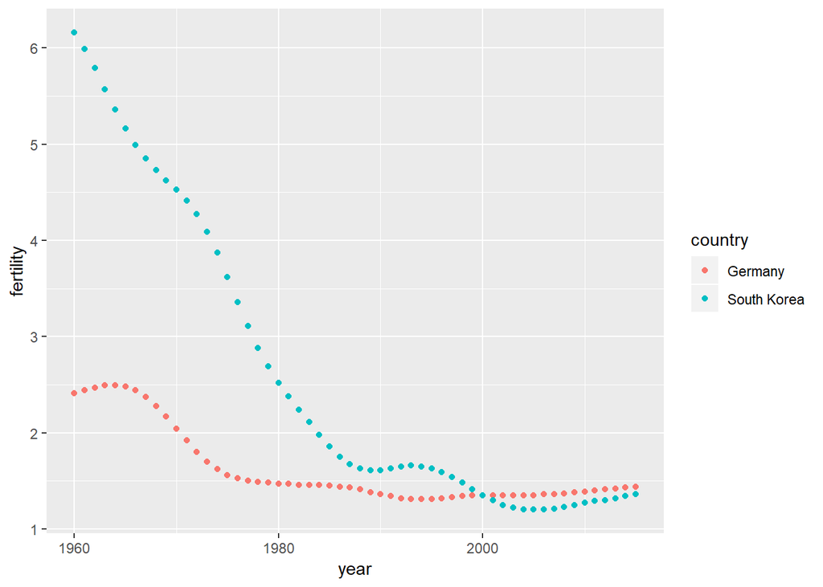

```r
library(ggplot2)
new_tidy_data %>% ggplot(aes(year, fertility, color = country)) + geom_point()
```

#### Tidy to Wide

*Tidyr’s* *spread()* function does the inverse of the *gather()* function, converting tidy data to wide data. The first argument of the *spread()* function is to declare which variables are to be used as column names. While the second argument is to specify the variables used to fill out the cells.

```r
new_wide_data <- new_tidy_data %>% spread(year, fertility)
select(new_wide_data, country, '1960':'1967')
```

```
## # A tibble: 2 x 9
##   country     `1960` `1961` `1962` `1963` `1964` `1965` `1966` `1967`
##   <chr>        <dbl>  <dbl>  <dbl>  <dbl>  <dbl>  <dbl>  <dbl>  <dbl>
## 1 Germany       2.41   2.44   2.47   2.49   2.49   2.48   2.44   2.37
## 2 South Korea   6.16   5.99   5.79   5.57   5.36   5.16   4.99   4.85
```

Here is a [cheat sheet](https://github.com/rstudio/cheatsheets/blob/master/data-import.pdf) on what we have learnt so far.

### Separate and Unite

Usually, data is in a more complicated form. Below we have a file with more than one variable and stored widely and in a sub-optimal way.

```r
path <- system.file("extdata", package = "dslabs")
filename <- file.path(path, "life-expectancy-and-fertility-two-countries-example.csv")
raw_dat <- read_csv(filename)
select(raw_dat, 1:5)
```

```
## # A tibble: 2 x 5
##   country `1960_fertility` `1960_life_expe~ `1961_fertility`
##   <chr>              <dbl>            <dbl>            <dbl>
## 1 Germany             2.41             69.3             2.44
## 2 South ~             6.16             53.0             5.99
## # ... with 1 more variable: `1961_life_expectancy` <dbl>
```

Now we will use the gather function to convert our data from wide to tidy. However, notice that we can’t name our column year as it also contains variable type. Instead, we will use the default key.

```r
dat <- raw_dat %>% gather(key, value, -country)
head(dat)
```

```
## # A tibble: 6 x 3
##   country     key                  value
##   <chr>       <chr>                <dbl>
## 1 Germany     1960_fertility        2.41
## 2 South Korea 1960_fertility        6.16
## 3 Germany     1960_life_expectancy 69.3
## 4 South Korea 1960_life_expectancy 53.0
## 5 Germany     1961_fertility        2.44
## 6 South Korea 1961_fertility        5.99
```

Notice how much messier this is with more realistic data. It is not yet tidy as we should separate our fertility and life expectancy into separate columns.

```r
dat$key[1:5]
```

```
## [1] "1960_fertility"       "1960_fertility"       "1960_life_expectancy"
## [4] "1960_life_expectancy" "1961_fertility"
```

The *separate()* function requires the target column, the names for the new columns and the separator character. As the “_" underscore is the default separator character, we do not have to specify the third argument in this case.

Here we add an additional second variable name to catch the second half of “life_expectancy” due to the underscore separating them. The keyword argument fill lets us specify which column to place NA values when there isn’t a third variable name.

```r
dat %>% separate(key, c("year", "first_variable_name", "second_variable_name"), fill = "right")
```

```
## # A tibble: 224 x 5
##    country     year  first_variable_name second_variable_name value
##    <chr>       <chr> <chr>               <chr>                <dbl>
##  1 Germany     1960  fertility           <NA>                  2.41
##  2 South Korea 1960  fertility           <NA>                  6.16
##  3 Germany     1960  life                expectancy           69.3
##  4 South Korea 1960  life                expectancy           53.0
##  5 Germany     1961  fertility           <NA>                  2.44
##  6 South Korea 1961  fertility           <NA>                  5.99
##  7 Germany     1961  life                expectancy           69.8
##  8 South Korea 1961  life                expectancy           53.8
##  9 Germany     1962  fertility           <NA>                  2.47
## 10 South Korea 1962  fertility           <NA>                  5.79
## # ... with 214 more rows
```

However, the keyword argument extra can also deal with this extra variable name from an unintended separate.

```r
dat %>% separate(key, c("year", "variable_name"), extra = "merge")
```

```
## # A tibble: 224 x 4
##    country     year  variable_name   value
##    <chr>       <chr> <chr>           <dbl>
##  1 Germany     1960  fertility        2.41
##  2 South Korea 1960  fertility        6.16
##  3 Germany     1960  life_expectancy 69.3
##  4 South Korea 1960  life_expectancy 53.0
##  5 Germany     1961  fertility        2.44
##  6 South Korea 1961  fertility        5.99
##  7 Germany     1961  life_expectancy 69.8
##  8 South Korea 1961  life_expectancy 53.8
##  9 Germany     1962  fertility        2.47
## 10 South Korea 1962  fertility        5.79
## # ... with 214 more rows
```

Notice that the data is still not tidy, the variable_name column contains two types of variables and we still have the value column. We must use *spread()* on these remaining portions of the data frame.

```r
dat %>% separate(key, c("year", "variable_name"), extra = "merge") %>% spread(variable_name, value)
```

```
## # A tibble: 112 x 4
##    country year  fertility life_expectancy
##    <chr>   <chr>     <dbl>           <dbl>
##  1 Germany 1960       2.41            69.3
##  2 Germany 1961       2.44            69.8
##  3 Germany 1962       2.47            70.0
##  4 Germany 1963       2.49            70.1
##  5 Germany 1964       2.49            70.7
##  6 Germany 1965       2.48            70.6
##  7 Germany 1966       2.44            70.8
##  8 Germany 1967       2.37            71.0
##  9 Germany 1968       2.28            70.6
## 10 Germany 1969       2.17            70.5
## # ... with 102 more rows
```

While not optimal in this case, we can use this example to showcase the *unite()* function.

```r
dat %>% separate(key, c("year", "first_variable_name", "second_variable_name"), fill = "right") %>% unite(variable_name, first_variable_name, second_variable_name) %>% spread(variable_name, value) %>% rename(fertility = fertility_NA)
```

```
## # A tibble: 112 x 4
##    country year  fertility life_expectancy
##    <chr>   <chr>     <dbl>           <dbl>
##  1 Germany 1960       2.41            69.3
##  2 Germany 1961       2.44            69.8
##  3 Germany 1962       2.47            70.0
##  4 Germany 1963       2.49            70.1
##  5 Germany 1964       2.49            70.7
##  6 Germany 1965       2.48            70.6
##  7 Germany 1966       2.44            70.8
##  8 Germany 1967       2.37            71.0
##  9 Germany 1968       2.28            70.6
## 10 Germany 1969       2.17            70.5
## # ... with 102 more rows
```

## Combining Data

Sometimes the information we need for an analysis might be in more than one table.

```r
load("polls_us_election_2016.rda")
```

Here you can see that because the order of the states are not the same in both tables, we cannot simply join the two tables.

```r
identical(results_us_election_2016$state, murders$state)
```

```
## [1] FALSE
```

The *join()* functions in the *dplyr* package are based on the [SQL joins](http://joins.spathon.com/) make sure that the tables are combined so that matching rows are together. We simply need to identify one or more columns that contain the information needed to match the two tables.

```r
tab <- left_join(murders, results_us_election_2016, by = "state")
head(tab)
```

```
##        state abb region population total electoral_votes clinton trump
## 1    Alabama  AL  South    4779736   135               9    34.4  62.1
## 2     Alaska  AK   West     710231    19               3    36.6  51.3
## 3    Arizona  AZ   West    6392017   232              11    45.1  48.7
## 4   Arkansas  AR  South    2915918    93               6    33.7  60.6
## 5 California  CA   West   37253956  1257              55    61.7  31.6
## 6   Colorado  CO   West    5029196    65               9    48.2  43.3
##   others
## 1    3.6
## 2   12.2
## 3    6.2
## 4    5.8
## 5    6.7
## 6    8.6
```

Here is a plot of the combined data.

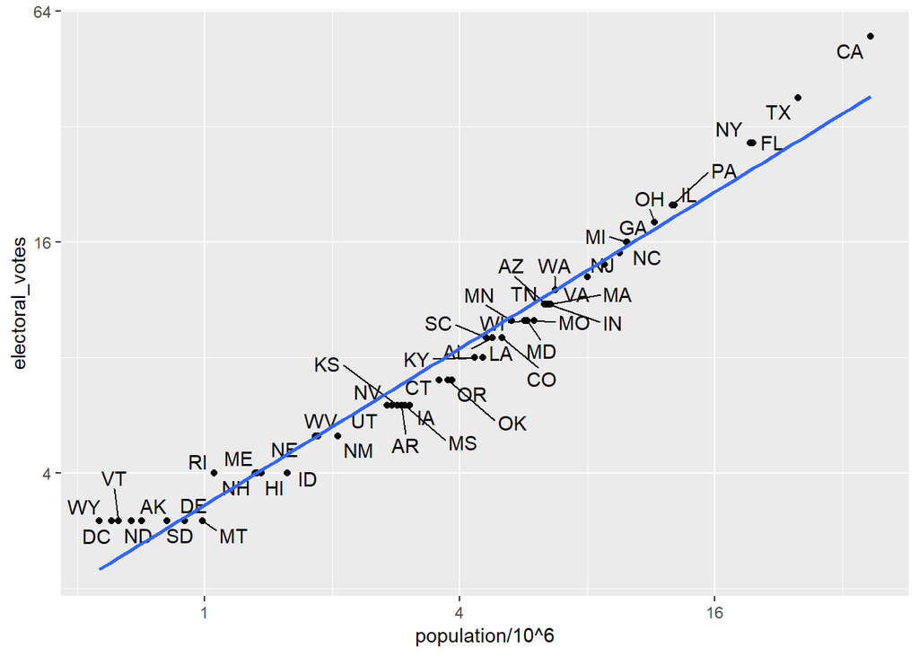

```r
library(ggrepel)
tab %>% ggplot(aes(population/10^6, electoral_votes, label = abb)) +
  geom_point() +
  geom_text_repel() +
  scale_x_continuous(trans = "log2") +
  scale_y_continuous(trans = "log2") +
  geom_smooth(method = "lm", se = FALSE)
```

Usually we won’t have a perfect match between two tables. We show this with subsets of both tables, so that the states in the subsets below will differ.

```r
tab1 <- slice(murders, 1:6) %>% select(state,population)
tab1
```

```
##        state population
## 1    Alabama    4779736
## 2     Alaska     710231
## 3    Arizona    6392017
## 4   Arkansas    2915918
## 5 California   37253956
## 6   Colorado    5029196
```

```r
tab2 <- slice(results_us_election_2016, c(1:3, 5, 7:8)) %>% select(state, electoral_votes)
tab2
```

```
##        state electoral_votes
## 1 California              55
## 2      Texas              38
## 3    Florida              29
## 4   Illinois              20
## 5       Ohio              18
## 6    Georgia              16
```

### Left Join

Notice what happens when we attempt the *left_join()* function again.

```r
left_join(tab1, tab2)
```

```
##        state population electoral_votes
## 1    Alabama    4779736              NA
## 2     Alaska     710231              NA
## 3    Arizona    6392017              NA
## 4   Arkansas    2915918              NA
## 5 California   37253956              55
## 6   Colorado    5029196              NA
```

The *join()* functions can also take advantage of the %>% pipe operator.

```r
tab1 %>% left_join(tab2)
```

```
##        state population electoral_votes
## 1    Alabama    4779736              NA
## 2     Alaska     710231              NA
## 3    Arizona    6392017              NA
## 4   Arkansas    2915918              NA
## 5 California   37253956              55
## 6   Colorado    5029196              NA
```

### Right Join

If we want the table like tab2, we can use the *right_join()* function

```r
tab1 %>% right_join(tab2)
```

```
##        state population electoral_votes
## 1 California   37253956              55
## 2      Texas         NA              38
## 3    Florida         NA              29
## 4   Illinois         NA              20
## 5       Ohio         NA              18
## 6    Georgia         NA              16
```

### Inner Join

If we only want information from rows in both tables, that is like an intersection, we instead use the *inner_join()* function.

```r
inner_join(tab1, tab2)   #notice that there will no NAs
```

```
##        state population electoral_votes
## 1 California   37253956              55
```

### Full Join

If we want to keep all rows in both tables, that is like a union, we instead use the *full_join()* function.

```r
full_join(tab1, tab2)   #notice that there will be all the NAs
```

```
##         state population electoral_votes
## 1     Alabama    4779736              NA
## 2      Alaska     710231              NA
## 3     Arizona    6392017              NA
## 4    Arkansas    2915918              NA
## 5  California   37253956              55
## 6    Colorado    5029196              NA
## 7       Texas         NA              38
## 8     Florida         NA              29
## 9    Illinois         NA              20
## 10       Ohio         NA              18
## 11    Georgia         NA              16
```

### Semi Join

The *semi_join()* function allows us to keep the part of the first table for which we have information in the second table, but doesnt add the columns of the second.

```r
semi_join(tab1, tab2)   #notice that there are less columns
```

```
##        state population
## 1 California   37253956
```

### Anti Join

The *anti_join()* function is the opposite of the *semi_join()* function. It allows us to keep the part of the first table for which we have **NO** information in the second table, but doesnt add the columns of the second.

```r
anti_join(tab1, tab2)   #notice that there are less rows and columns
```

```
##      state population
## 1  Alabama    4779736
## 2   Alaska     710231
## 3  Arizona    6392017
## 4 Arkansas    2915918
## 5 Colorado    5029196
```

## Set Operators

These set operators work like union and intersect for vectors. If the *dplyr* package is loaded, these functions also work on the dataframe.

### Intersect

We can take the *intersect()* of numeric or character vectors.

```r
intersect(1:10, 6:15)
```

```
## [1]  6  7  8  9 10
```

```r
intersect(c("a","b","c"), c("b","c","d"))
```

```
## [1] "b" "c"
```

However with *dplyr* package loaded, we can also do this for tables where they have the same column names.

```r
library(dplyr)
tab1 <- tab[1:5,]
tab2 <- tab[3:7,]
intersect(tab1, tab2)
```

```
##        state abb region population total electoral_votes clinton trump
## 1    Arizona  AZ   West    6392017   232              11    45.1  48.7
## 2   Arkansas  AR  South    2915918    93               6    33.7  60.6
## 3 California  CA   West   37253956  1257              55    61.7  31.6
##   others
## 1    6.2
## 2    5.8
## 3    6.7
```

### Union

We can do the same with the *union()* function.

```r
tab1 <- tab[1:5,]
tab2 <- tab[3:7,]
union(tab1, tab2)
```

```
##         state abb    region population total electoral_votes clinton trump
## 1    Arkansas  AR     South    2915918    93               6    33.7  60.6
## 2     Arizona  AZ      West    6392017   232              11    45.1  48.7
## 3      Alaska  AK      West     710231    19               3    36.6  51.3
## 4  California  CA      West   37253956  1257              55    61.7  31.6
## 5     Alabama  AL     South    4779736   135               9    34.4  62.1
## 6    Colorado  CO      West    5029196    65               9    48.2  43.3
## 7 Connecticut  CT Northeast    3574097    97               7    54.6  40.9
##   others
## 1    5.8
## 2    6.2
## 3   12.2
## 4    6.7
## 5    3.6
## 6    8.6
## 7    4.5
```

### Setdiff

We can also get the set difference with *setdiff()*. Unlike *intersect()* and *union()* function, the function is asymmetrical.

```r
setdiff(1:10, 6:15)   #notice there are two different answers
```

```
## [1] 1 2 3 4 5
```

```r
setdiff(6:15, 1:10)
```

```
## [1] 11 12 13 14 15
```

However with *dplyr* package loaded, we can also do this for tables where they have the same column names.

```r
library(dplyr)
tab1 <- tab[1:5,]
tab2 <- tab[3:7,]
setdiff(tab1, tab2)
```

```
##     state abb region population total electoral_votes clinton trump others
## 1 Alabama  AL  South    4779736   135               9    34.4  62.1    3.6
## 2  Alaska  AK   West     710231    19               3    36.6  51.3   12.2
```

### Setequal

The *setequal()* function helps us check if two sets are the same regardless of order.

```r
setequal(1:5, 1:6)
```

```
## [1] FALSE
```

```r
setequal(1:5, 5:1)
```

```
## [1] TRUE
```

However with *dplyr* package loaded, we can also do this for dataframes as well.

```r
setequal(tab1, tab2)  #note the useful return output
```

```
## [1] FALSE
```